# Introducción a las probabilidades (parte I)

# *Conceptos Básicos de Probabilidades*

## *1.Experimentos Aleatorios*

Definición :

Según Montgomery y Runger (2018); “Un experimento aleatorio es aquel que puede tener diferentes resultados, aunque se repita de la misma manera cada vez que se realiza” (p. 18).

## *2.Espacio Muestral*

Definición :

Según Montgomery y Runger (2018) “La colección de todos los posibles resultados de un experimento aleatorio se llama espacio muestral del experimento. El espacio muestral se denota como *S* .” (p.20)

Este puede ser continuo o discreto. Dos ejemplos rápido para contrastar. Para el continuo puede ser el peso corporal de los pacientes de un hospital. Y discreto las caras de un dado.

## *3.Eventos*

Definición :

Según Montgomery y Runger (2018) “Un evento es un subconjunto del espacio muestral de un experimento aleatorio.” (p.21)

## Ejemplos

1 ) Lanzar una moneda donde su espacio muestral es :

$\Omega$ = {Cara, Sello}

Para el lanzamiento de dos monedas un evento podría ser que “las monedas caigan del mismo lado”, donde el espacio muestral es:

*S* = {Cara Cara, Cara Sello, Sello Cara , Sello Sello}

pero el evento que nos interesa es el subconjunto :

*E* = {Cara Cara, Sello Sello}

[figure not shown]

2 ) Lanzamiento de un dado de 6 caras donde su espacio muestral es :

$\Omega$ = {1, 2, 3, 4, 5, 6}

Para este ejemplo un evento podría ser que “que resulte una número impar”, donde el subconjunto de interés es: *E* = {1,3,5}

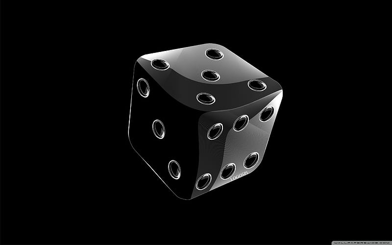

# *Interpretación Axiomas de Probabilidades*

## *1.Resultados igualmente probables o equiprobables*

Definición :

“Cuando un espacio muestral consiste en N posibles resultados que son igualmente probables, la probabilidad de cada resultado es 1/N.” Montgomery(2018, p.27)

Un ejemplo es para un dado de 6 caras *NO* cargado, donde cada una de sus caras tiene *P(x) = $\frac{1}{6}$* , considerando que x $\in$ $\Omega$ .

## *2.Probablilidad de un evento*

Definición :

“Para un espacio muestral discreto, la probabilidad de un evento *E*, representada como *P(E)*, es igual a la suma de las probabilidades de los resultados en *E*.” Montgomery(2018, p.28)

Un ejemplo es el del dado donde sabemos que su espacio muestral está contemplado por :

$\Omega$ = {1, 2, 3, 4, 5, 6}

Y un evento podría ser que “que resulte una número impar”, donde el subconjunto es:

*E* = {1,3,5}

Ahora sabiendo que la probabilidad de cada cara es de $\frac{1}{6}$ entonces,

*P(E) = $\frac{1}{6} \times 3 = \frac{3}{6} = \frac{1}{2}$*

## *3.Axiomas de probabilidad*

Definición :

“La probabilidad es un número que se asigna a cada miembro de una colección de eventos de un experimento aleatorio que cumple con las siguientes propiedades:

1. *P(S) = 1* donde **S** es el espacio muestral.
2. $0 \geq P(E) \geq 1$ para cualquier evento *E*
3. Para dos eventos $E_1$ y $E_2$ con $E_1 \cap E_2 =\emptyset$ $P(E_1 \cup E_2) = P(E_1) + P(E_2)$ ”

# Bibliografía

[1] Montgomery, D. C., & Runger, G. C. (2018). Applied statistics and probability for engineers (7th ed.). Wiley.